# Introduction to Resource Selection

### How Many Points is Enough?

Before we move on to final model fitting, we must first the address the question of whether or not we have adequately sampled “Availability”. Ultimately, this is a trade-off between statistical robustness and computer processing time. I generally perform this on a single individual as evidence that I am appropriately sampling from availability.

The process simply entails “looping” over a differ set of availability (from 1 “Available” point per “Use” point to 100 “Available” points per “Use” point). We will use a nested structure, rather than the “for loop” structure, that we have demonstrated in previous exercises. For this complicated process, I think the nested structure is a bit easier. We then do this process multiple times, so that the “Available” points differ and so we can evaluate how much the coefficients change between model fittings.

**NOTE: THIS CAN TAKE A LONG TIME BECAUSE YOU ARE FITTING MULTIPLE DIFFERENT MODELS WITH MANY DATA POINTS**

```r
# Exploring sensitivity of RSF coefficients to the number of available points

# Setup number of available locations to sample
n.frac <- c(1, 5, 20, 50, 100)

# Total available locations to be generated, based on the number of Use points
n.pts <- nrow(wb) * n.frac

# Number of replicates of each available location (1,5,20,50,100)
# This is number of times each model will be fit, allows to calculate variability
# For a publication, I would increase the n.rep to 100
n.rep <- 20

# Create a table which can hold the n.reps
# Extract covariates from rsf.stack
# Rename the variables
# Fit glm model for each available location (1,5,20,50,100) and for each replication (re-sampling)

# Commenting out because the process is time consuming
# *******************************************
# *******************************************
# wb.sim <- tibble(
#   n.pts = rep(n.pts, n.rep),
#   frac = rep(n.frac, n.rep),
#   result = map(
#     n.pts, ~
#       wb %>% random_points(n = .x) %>%
#       extract_covariates(rsf.stack) %>%
#       mutate(anth_risk= scale(anth_risk),
#              woody_dist = scale(woody_dist),
#              fence_dist = scale(fence_dist),
#              prirds_dist = scale(prirds_dist),
#              river_dist = scale(river_dist),
#              secrds_dist = scale(secrds_dist),
#              waterpts_dist = scale(waterpts_dist)) %>%
#       glm(case_ ~ anth_risk + woody_dist + fence_dist + prirds_dist + river_dist + secrds_dist + waterpts_dist,
#           data = ., family = binomial(link = "logit")) %>%
#       tidy()))

wb.sim # We see the structure has 100 rows (n.frac (5) x n.rep (20) = 100) # File loaded at the beginning of script
```

```
## # A tibble: 100 x 3
##     n.pts  frac result
##     <dbl> <dbl> <list>
##  1   1176     1 <tibble [8 x 5]>
##  2   5880     5 <tibble [8 x 5]>
##  3  23520    20 <tibble [8 x 5]>
##  4  58800    50 <tibble [8 x 5]>
##  5 117600   100 <tibble [8 x 5]>
##  6   1176     1 <tibble [8 x 5]>
##  7   5880     5 <tibble [8 x 5]>
##  8  23520    20 <tibble [8 x 5]>
##  9  58800    50 <tibble [8 x 5]>
## 10 117600   100 <tibble [8 x 5]>
## # ... with 90 more rows
```

```r
#str(wb.sim)
wb.sim$result[[1]]
```

```
## # A tibble: 8 x 5
##   term          estimate std.error statistic  p.value
##   <chr>            <dbl>     <dbl>     <dbl>    <dbl>
## 1 (Intercept)    -0.0103    0.0463    -0.223 8.23e- 1
## 2 anth_risk      -0.207     0.0488    -4.23  2.29e- 5
## 3 woody_dist     -1.05      0.108     -9.71  2.72e-22
## 4 fence_dist     -0.653     0.116     -5.63  1.81e- 8
## 5 prirds_dist    -0.165     0.0842    -1.96  5.00e- 2
## 6 river_dist      0.0135    0.0501     0.269 7.88e- 1
## 7 secrds_dist     0.193     0.0578     3.34  8.49e- 4
## 8 waterpts_dist  -0.228     0.0979    -2.33  1.96e- 2
```

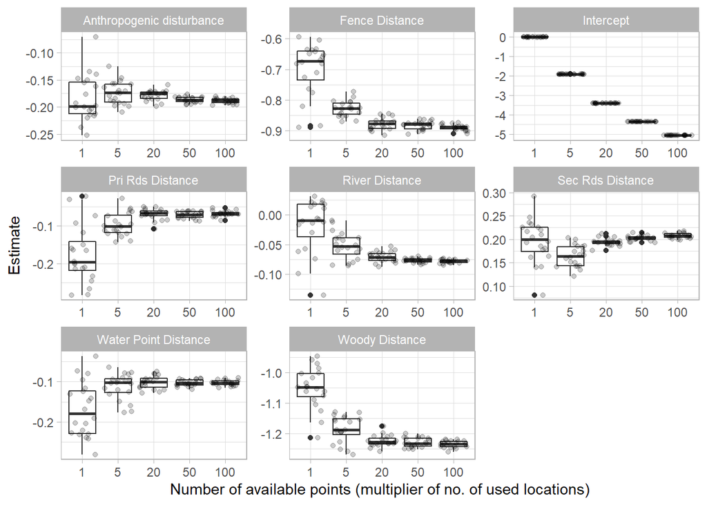

```r
# We now "unnest" the results to plot the coefficient estimates from individual model fits with different sets of available data (1,5,20,100)
wb.sim %>% unnest(cols = result) %>%
  mutate(wb.sim = recode(term, "(Intercept)"="Intercept",
                         anth_risk = "Anthropogenic disturbance",
                         woody_dist = "Woody Distance",
                         fence_dist = "Fence Distance",
                         prirds_dist = "Pri Rds Distance",
                         river_dist = "River Distance",
                         secrds_dist = "Sec Rds Distance",
                         waterpts_dist = "Water Point Distance")) %>%
  ggplot(aes(factor(frac), y = estimate)) +
  geom_boxplot() + facet_wrap(~ wb.sim, scale  ="free") +
  geom_jitter(alpha = 0.2) +
  labs(x = "Number of available points (multiplier of no. of used locations)",
       y = "Estimate") +
  theme_light()
```

### Model Fitting

Based on the model fitting simulations, we will generate 50 available locations per use location. More would be better, but there is seemingly little change between model fits. We will follow the same process described above.

```r
# Generating 20 available locations per each used location within animal homerange
wb_RSF50 <- random_points(wb,n=nrow(wb)*50,typ="random")

# Extracting the covariates
wb_RSF50 <- wb_RSF50 %>% extract_covariates(rsf.stack)

# Fitting model
M2 <- glm(case_ ~ scale(anth_risk) + scale(fence_dist) + scale(waterpts_dist) + scale(prirds_dist) + scale(river_dist) + scale(secrds_dist) +  + scale(woody_dist),
         family = binomial(link="logit"),
         data =wb_RSF50)
# Get Summary & confidence intervals
summary(M2)
```

```
##
## Call:
## glm(formula = case_ ~ scale(anth_risk) + scale(fence_dist) +
##     scale(waterpts_dist) + scale(prirds_dist) + scale(river_dist) +
##     scale(secrds_dist) + +scale(woody_dist), family = binomial(link = "logit"),
##     data = wb_RSF50)
##
## Deviance Residuals:
##     Min       1Q   Median       3Q      Max
## -0.5698  -0.2187  -0.1536  -0.1086   3.6225
##
## Coefficients:
##                      Estimate Std. Error  z value Pr(>|z|)
## (Intercept)          -4.35733    0.04141 -105.214  < 2e-16 ***
## scale(anth_risk)     -0.18700    0.03067   -6.097 1.08e-09 ***
## scale(fence_dist)    -1.01634    0.08622  -11.788  < 2e-16 ***
## scale(waterpts_dist) -0.15519    0.06835   -2.271  0.02317 *
## scale(prirds_dist)   -0.17123    0.05585   -3.066  0.00217 **
## scale(river_dist)    -0.17247    0.03222   -5.353 8.66e-08 ***
## scale(secrds_dist)    0.12472    0.03839    3.249  0.00116 **
## scale(woody_dist)    -1.06885    0.06852  -15.599  < 2e-16 ***
## ---
## Signif. codes:  0 '***' 0.001 '**' 0.01 '*' 0.05 '.' 0.1 ' ' 1
##
## (Dispersion parameter for binomial family taken to be 1)
##
##     Null deviance: 11576  on 59975  degrees of freedom
## Residual deviance: 10542  on 59968  degrees of freedom
## AIC: 10558
##
## Number of Fisher Scoring iterations: 7
```

```r
confint(M2)
```

```
##                            2.5 %      97.5 %
## (Intercept)          -4.43977278 -4.27738380
## scale(anth_risk)     -0.24798333 -0.12773955
## scale(fence_dist)    -1.18588994 -0.84784483
## scale(waterpts_dist) -0.29007224 -0.02211072
## scale(prirds_dist)   -0.28120048 -0.06221863
## scale(river_dist)    -0.23611759 -0.10978938
## scale(secrds_dist)    0.04911264  0.19966346
## scale(woody_dist)    -1.20361395 -0.93497597
```

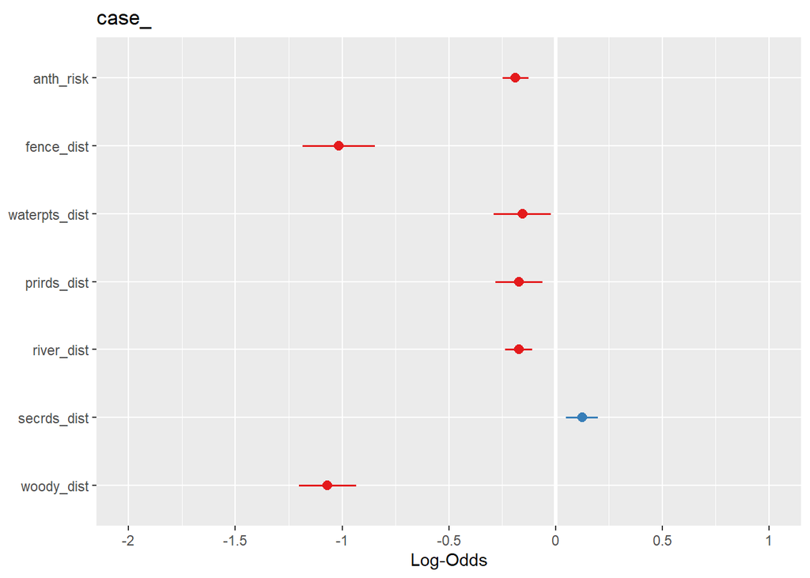

```r
# Plot coefficients (an easy alternative to coefplot - THANKS Pawel!!)
plot_model(M2,transform = NULL)
```

```r
# To get the odds ratios instead of coefficients on the logit scale, exponentiate the coefficient estimates
# Example: exp(M2$coefficients[2]) or exp(-0.1261324)
# Or easier, use tab_model from sjPlot
tab_model(M2)
```

```
## Profiled confidence intervals may take longer time to compute. Use 'df_method="wald"' for faster computation of CIs.
```

|  | case_ |  |  |
| --- | --- | --- | --- |
| Predictors | Odds Ratios | CI | p |
| (Intercept) | 0.01 | 0.01 – 0.01 | **<0.001** |
| anth_risk | 0.83 | 0.78 – 0.88 | **<0.001** |
| fence_dist | 0.36 | 0.31 – 0.43 | **<0.001** |
| waterpts_dist | 0.86 | 0.75 – 0.98 | **0.023** |
| prirds_dist | 0.84 | 0.75 – 0.94 | **0.002** |
| river_dist | 0.84 | 0.79 – 0.90 | **<0.001** |
| secrds_dist | 1.13 | 1.05 – 1.22 | **0.001** |
| woody_dist | 0.34 | 0.30 – 0.39 | **<0.001** |
| Observations | 59976 |  |  |
| R<sup>2</sup> Tjur | 0.024 |  |  |

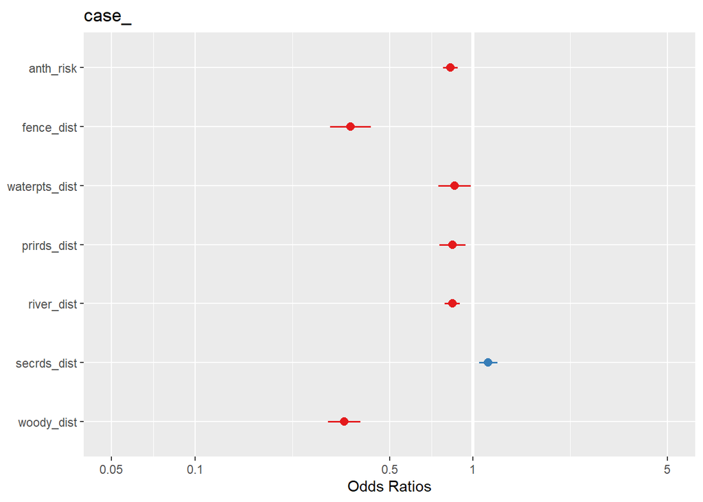

```r
plot_model(M2)
```

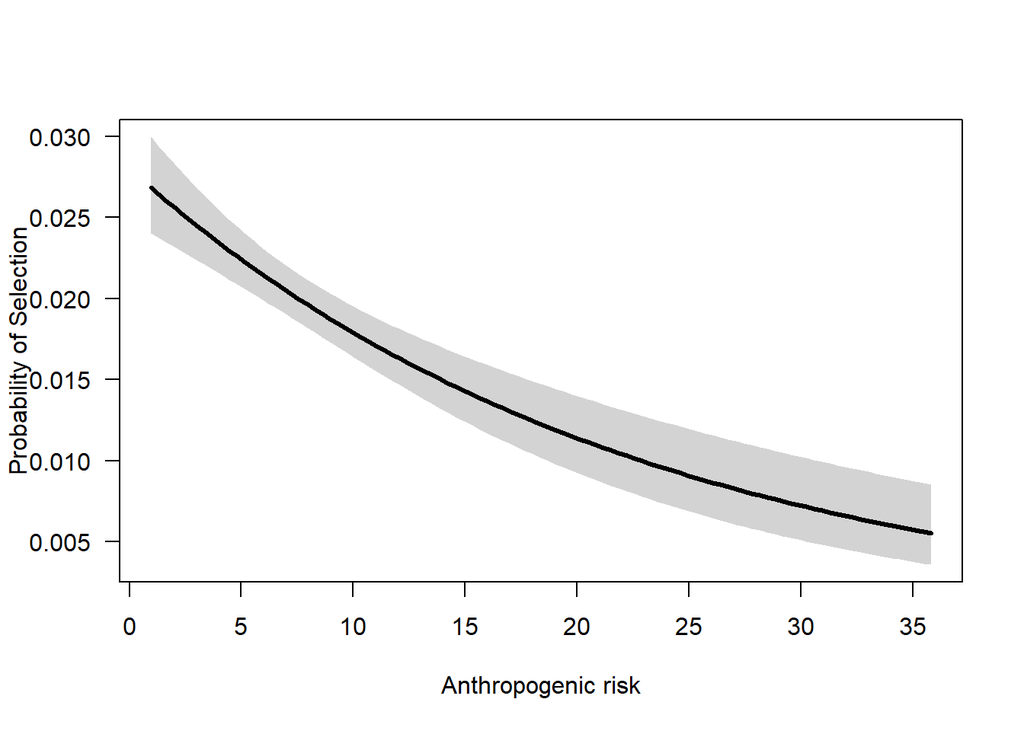

```r
# There are multiple ways to graph the response curves.  In addition to visreg, we could also plot using jtools or sjplot (many others)
visreg(M2,"anth_risk",
       scale="response",
       ylab="Probability of Selection",
       xlab="Anthropogenic risk",
       partial=F,
       rug=F,
       line=list(col="black"),
       fill=list(col="light gray"))
```

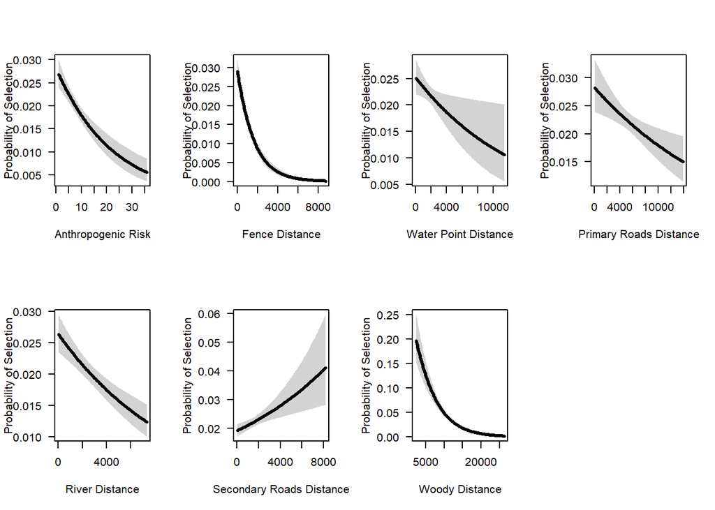

```r
# Let's loop over all the variables
par(mfrow=c(2,4))
var1 <- c("anth_risk","fence_dist","waterpts_dist","prirds_dist","river_dist","secrds_dist","woody_dist")
var2 <- c("Anthropogenic Risk","Fence Distance","Water Point Distance","Primary Roads Distance","River Distance","Secondary Roads Distance","Woody Distance")

par(mfrow=c(2,4))
for (i in 1:length(var1)){
visreg(M2,var1[i],
       scale="response",
       ylab="Probability of Selection",
       xlab=var2[i],
       partial=F,
       rug=F,
       line=list(col="black"),
       fill=list(col="light gray"))
}
par(mfrow=c(1,1))
```

### Generate Model Prediction

Last step is to generate a predictive surface of habitat suitability. First step is to extract the coefficients of each predictor included in the model summary. We can’t use `Predict` in this case, because we want to ignore the intercept. Remeber that we **must** scale the reaster values when making the prediction, since our coefficient estimates are based on scaled variables.

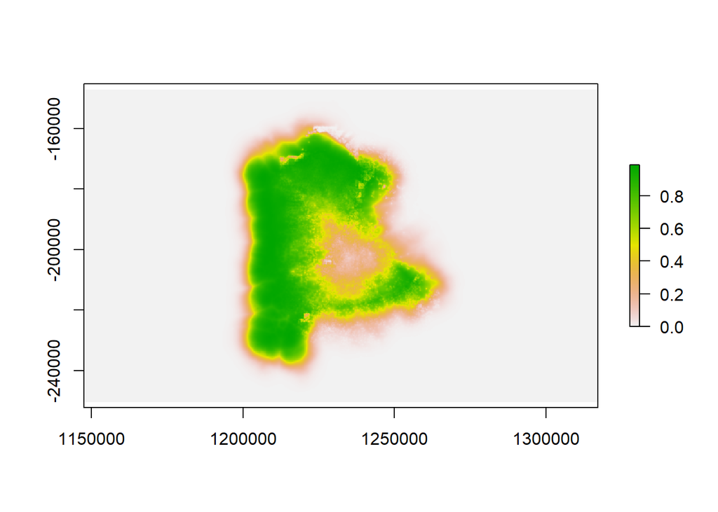

```r
# Extract the coefficient of each predictor from the model summary
coeff <- M2$coefficients

# Then, use the logistic equation to generate predictions (no B_0)
# w*(x)=exp(β1x1 + β2x2 +.... + βnxn)/exp(1 + β1x1 + β2x2 +.... + βnxn)

# where w*(x) is the relative probability of selection, dependent upon covariates X1 through Xn, and their estimated regression coefficients β1 to βn, respectively.

# Remember that we must scale the raster layers too:
anth.scale <- (anth_risk - mean(wb_RSF50$anth_risk)) / sd(wb_RSF50$anth_risk)
fence.scale <- (fence_dist - mean(wb_RSF50$fence_dist)) / sd(wb_RSF50$fence_dist)
water.scale <- (prirds_dist - mean(wb_RSF50$prirds_dist)) / sd(wb_RSF50$prirds_dist)
prirds.scale <- (secrds_dist - mean(wb_RSF50$secrds_dist)) / sd(wb_RSF50$secrds_dist)
river.scale <- (river_dist - mean(wb_RSF50$river_dist)) / sd(wb_RSF50$river_dist)
secrds.scale <- (waterpts_dist - mean(wb_RSF50$waterpts_dist)) / sd(wb_RSF50$waterpts_dist)
woody.scale <- (woody_dist - mean(wb_RSF50$woody_dist)) / sd(wb_RSF50$woody_dist)

# Prediction
pred <- exp(anth.scale*coeff[[2]]+ fence.scale*coeff[[3]] + water.scale*coeff[[4]] + prirds.scale*coeff[[5]] + river.scale*coeff[[6]] + secrds.scale*coeff[[7]] + woody.scale*coeff[[8]])/(1+exp(anth.scale*coeff[[2]]+ fence.scale*coeff[[3]] + water.scale*coeff[[4]] + prirds.scale*coeff[[5]] + river.scale*coeff[[6]] + secrds.scale*coeff[[7]] + woody.scale*coeff[[8]]))

# Provide Spatial Prediction - Based off of the coefficients from this single animal
plot(pred)
```

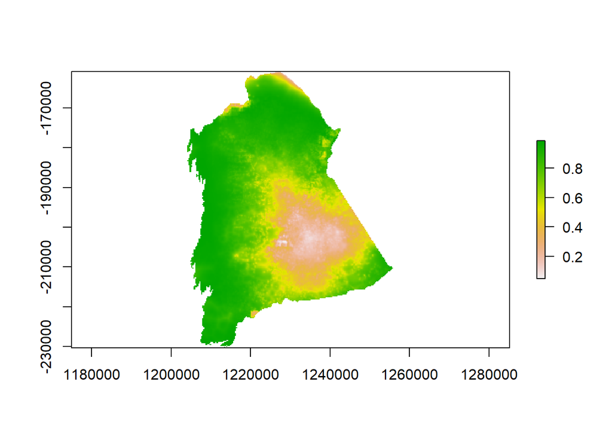

```r
# We could then mask this data layer, and then use tmap an place the layer on top of a map service (like we did with the Addax)
# We loaded a spatial polygon data layer at the start of this script named "Athi_Bound"
# Create new layer and crop it to the analysis extent
pred.mask <- mask(pred, Athi_Bound)
pred.mask <- crop(pred.mask,y=extent(Athi_Bound))
plot(pred.mask)
```

## Fitting a Model for Multiple Animals

More than likely, you will have multiple tagged animals and will be interested in investigating resource use across your entrepopulation (or interested in differences in selection between different populations). This can be accomplished in multiple ways:

- Two-stage approach
  - Fit a glm model for each individuals
  - Average the coefficients
- Account for individual random effects
  - Generalized Linear Mixed Effects Regression (GLMER)

### Two Stage Approach

The two stage approach follows the same procedure as described above, except that you would select additional animals and fit a GLM to each individual. You could then output the summary coefficients and either apply the mean of your coefficients (e.g., `mn.coeff.anth = mean(c(model1.coeff.anth, model2.coeff.anth, model3.coeff.anth))`) to the scaled raster layers or create individual predictions and calculate the mean of the predictive surfaces. Estimating the variance between animals, however, is very difficult. Model structures must be exactly the same between individuals in order to make comparisons.

Example of the command to calculate the mean of predictions from multiple animals:

`mean.pred <- mean(pred.mask.Animal1,pred.mask.Animal2,pred.mask.Animal3)`

### Generalized Linear Mixed Effects Regression

Mixed effects models are commonly used to provide estimates of the population. The same process as described above is used, but the model structure is slightly more complicated. Amt provides a nice structure for creating random points, with a simple process for annotating points with underlying environmental layers. This information is being provided to those that have animal tracking datasets and plan to work on analyses.

#### Generating Use/Availability

The dataframe needs to be converted to a list, with a dataframe for each animal. The `lapply` command can then be used to make a track (`mk_track`) and generate a set of random points (`random_points`).

```r
# Create object of ids
wild.An <- unique(wild.Athi$id)
# Creating list that contain the dataframe for each individual
wild.Athi<-split(wild.Athi,wild.Athi$id)

# Creating track for each individual animal in the list
wild.track <- lapply(wild.Athi, function(x) mk_track(x,
         .x=easting,.y=northing,
         .t=timestamp,crs = sp::CRS(AEA.Africa.proj)))

# Let's reduce the file, selecting only 20% of each use dataset
wild.track <- lapply(wild.track, function(x) x[sample(1:nrow(x),size = ceiling(nrow(x)*0.20)),c("x_","y_","t_")])

# Generate 50 random points for each animal
# Using a list apply here to apply the function
wb.Athi <- lapply(wild.track, function(x) random_points(x, n=nrow(x) * 50,typ="random"))
```

#### Extract Environmental Variables

We can then extract the relevant base layer information at each data point, similar to above, but by applying the `extract_covariates` to the list.

```r
# Adding anthropogenic risk covariate to each dataframe by using extract_covariates function
wb.Athi <- lapply(wb.Athi, function(x) extract_covariates(x, rsf.stack))

# Adding animal ID to each dataframe in the list.  We'll use this as the random effect.
wb.Athi <- mapply(cbind, wb.Athi, "Animal_ID" = wild.An, SIMPLIFY=F)

# Binding all dataframes in the list into a single dataframe for analysis
wb.Athi <- do.call(rbind,wb.Athi)
```

### Model Fitting

The model structure looks similar to what we have already done together, except we are now adding a random effect (1|Animal)

```r
# This model will be slow to execute
mixed.model <- glmer(case_ ~ scale(anth_risk) + scale(fence_dist) + scale(waterpts_dist) + scale(prirds_dist) + scale(river_dist) + scale(secrds_dist) +  + scale(woody_dist) + (1|Animal_ID),
                family = binomial(link="logit"),
                data = wb.Athi)

# Print Model Summary
summary(mixed.model)
```

#### Generate Model Prediction

Similar to earlier exercises, graph and interpret results

```r
# Plot coefficients and response curves for inference at the population level
plot_model(mixed.model,transform = NULL)

# Exponentiate the coefficients and plot the odds ratios
tab_model(mixed.model)
plot_model(mixed.model)

# Graph response curves.  Use effect plot from jtools.  Executes much quicker
effect_plot(mixed.model,data=wb.Athi,
            pred=anth_risk,interval = TRUE,
            x.label = "Anthropogenic risk",
            y.label = "Probability of selection") +
  theme_classic()
```

#### Generate Model Prediction

Recalculate the scaled rasters and predict a surface

```r
# Extract the coefficient of each predictor from the model summary
coef <- summary(mixed.model)
coeff <- coef$coefficients

# Scale rasters:
anth.scale <- (anth_risk - mean(wb.Athi$anth_risk)) / sd(wb.Athi$anth_risk)
fence.scale <- (fence_dist - mean(wb.Athi$fence_dist)) / sd(wb.Athi$fence_dist)
water.scale <- (prirds_dist - mean(wb.Athi$prirds_dist)) / sd(wb.Athi$prirds_dist)
prirds.scale <- (secrds_dist - mean(wb.Athi$secrds_dist)) / sd(wb.Athi$secrds_dist)
river.scale <- (river_dist - mean(wb.Athi$river_dist)) / sd(wb.Athi$river_dist)
secrds.scale <- (waterpts_dist - mean(wb.Athi$waterpts_dist)) / sd(wb.Athi$waterpts_dist)
woody.scale <- (woody_dist - mean(wb.Athi$woody_dist)) / sd(wb.Athi$woody_dist)

# Prediction
pred.mixed <- exp(anth.scale*coeff[[2]]+ fence.scale*coeff[[3]] + water.scale*coeff[[4]] + prirds.scale*coeff[[5]] + river.scale*coeff[[6]] + secrds.scale*coeff[[7]] + woody.scale*coeff[[8]])/(1+exp(anth.scale*coeff[[2]]+ fence.scale*coeff[[3]] + water.scale*coeff[[4]] + prirds.scale*coeff[[5]] + river.scale*coeff[[6]] + secrds.scale*coeff[[7]] + woody.scale*coeff[[8]]))

# Provide Spatial Prediction - Based off of the coefficients from this single animal
plot(pred.mixed)

# We could then mask this data layer, and then use tmap an place the layer on top of a map service (like we did with the Addax)
# We loaded a spatial polygon data layer at the start of this script named "Athi_Bound"
# Create new layer and crop it to the analysis extent
pred.mixed.mask <- mask(pred.mixed, Athi_Bound)
pred.mixed.mask <- crop(pred.mixed.mask,y=extent(Athi_Bound))
plot(pred.mixed.mask)
```

# Next Steps/Key Questions

- How to incorporate the animal’s movement into the size of the buffer (SSF analysis)?
- How to validate results?
- How to create multiple competing hypotheses and select the best model based on AIC?